# STT 3851 Project 1

Kassidy Borum, Adam Seagle, Jordan Greene

4/06/2020

# 1 Data Summary

Summary and Glimpse:

```
##        id            price            size            lot
##  Min.   : 1.00   Min.   :155.5   Min.   :1.440   Min.   : 1.000
##  1st Qu.:19.75   1st Qu.:242.8   1st Qu.:1.861   1st Qu.: 3.000
##  Median :38.50   Median :276.0   Median :1.966   Median : 4.000
##  Mean   :38.50   Mean   :285.8   Mean   :1.970   Mean   : 3.987
##  3rd Qu.:57.25   3rd Qu.:336.8   3rd Qu.:2.107   3rd Qu.: 5.000
##  Max.   :76.00   Max.   :450.0   Max.   :2.896   Max.   :11.000
##       bath          bedrooms       yearbuilt    agestandardized
##  Min.   :1.000   Min.   :2.000   Min.   :1905   Min.   :-6.50000
##  1st Qu.:2.000   1st Qu.:3.000   1st Qu.:1958   1st Qu.:-1.22500
##  Median :2.000   Median :3.000   Median :1970   Median :-0.05000
##  Mean   :2.208   Mean   :3.447   Mean   :1969   Mean   :-0.05921
##  3rd Qu.:3.000   3rd Qu.:4.000   3rd Qu.:1980   3rd Qu.: 1.00000
##  Max.   :3.100   Max.   :6.000   Max.   :2005   Max.   : 3.50000
##    garagesize       status              elem
##  Min.   :0.000   Length:76          Length:76
##  1st Qu.:1.000   Class :character   Class :character
##  Median :2.000   Mode  :character   Mode  :character
##  Mean   :1.566
##  3rd Qu.:2.000
##  Max.   :3.000
```

```
## Rows: 76
## Columns: 11
## $ id              <dbl> 1, 2, 3, 4, 5, 6, 7, 8, 9, 10, 11, 12, 13, 14, 15, 16…
## $ price           <dbl> 388.0, 450.0, 386.0, 350.0, 155.5, 220.0, 239.5, 207.…
## $ size            <dbl> 2.180, 2.054, 2.112, 1.442, 1.800, 1.965, 1.800, 2.25…
## $ lot             <dbl> 4, 5, 5, 6, 1, 5, 4, 4, 4, 5, 5, 4, 4, 5, 4, 5, 4, 3,…
## $ bath            <dbl> 3.0, 3.0, 2.0, 1.0, 2.0, 2.0, 1.1, 2.0, 2.1, 2.1, 2.0…
## $ bedrooms        <dbl> 4, 4, 4, 2, 4, 3, 4, 4, 4, 3, 3, 4, 3, 3, 4, 3, 4, 3,…
## $ yearbuilt       <dbl> 1940, 1957, 1955, 1956, 1994, 1940, 1958, 1961, 1965,…
## $ agestandardized <dbl> -3.0, -1.3, -1.5, -1.4, 2.4, -3.0, -1.2, -0.9, -0.5, …
## $ garagesize      <dbl> 0, 2, 2, 1, 1, 1, 1, 2, 2, 2, 2, 2, 2, 2, 2, 2, 2, 2,…
## $ status          <chr> "sld", "sld", "sld", "act", "sld", "sld", "act", "sld…
## $ elem            <chr> "edison", "edison", "edison", "adams", "adams", "adam…
```

### Data Summary conclusions

**Examine the statistics and values for each variable. Are any missing? Do any values need clarification or modification? If so, why and what did you do?**

Nothing seems out of place here. Summary does not report any missing values and the data all seems to be reasonable given the parameters. The only number that caught my attention initially was the 3.1 bath, but I would assume that means there is an extra vanity sink in the house that counts as that extra 0.1. I would also note that we change the `status` and `elem` variables to factors.

# 2 Exploratory Data Analysis

Numerical summary of variable correlation to `price`:

```
##              id           price            size             lot            bath
##      0.04662108      1.00000000      0.20143783      0.24423228      0.17465777
##        bedrooms       yearbuilt agestandardized      garagesize
##     -0.28619746      0.15412476      0.15412476      0.35838608
```

Correlation graph:

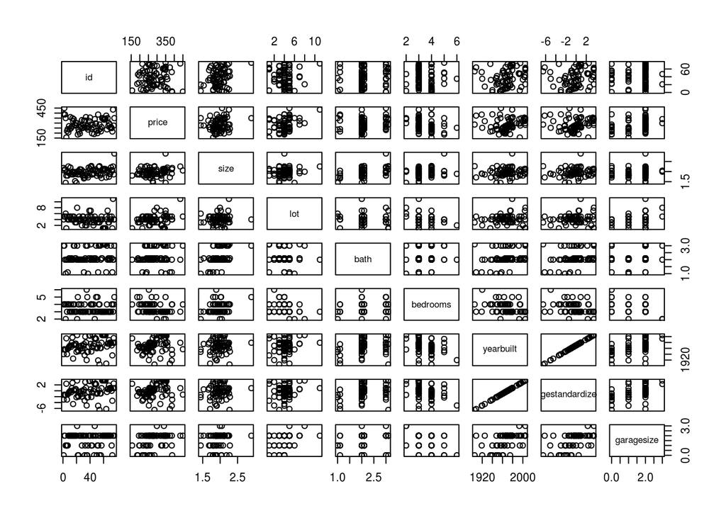

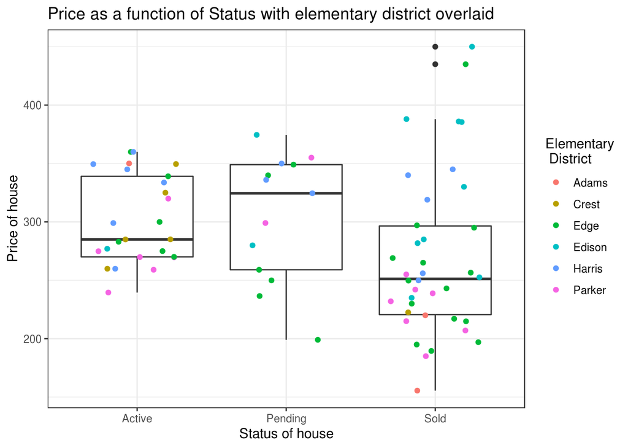

Figure 2.1: Price per Status

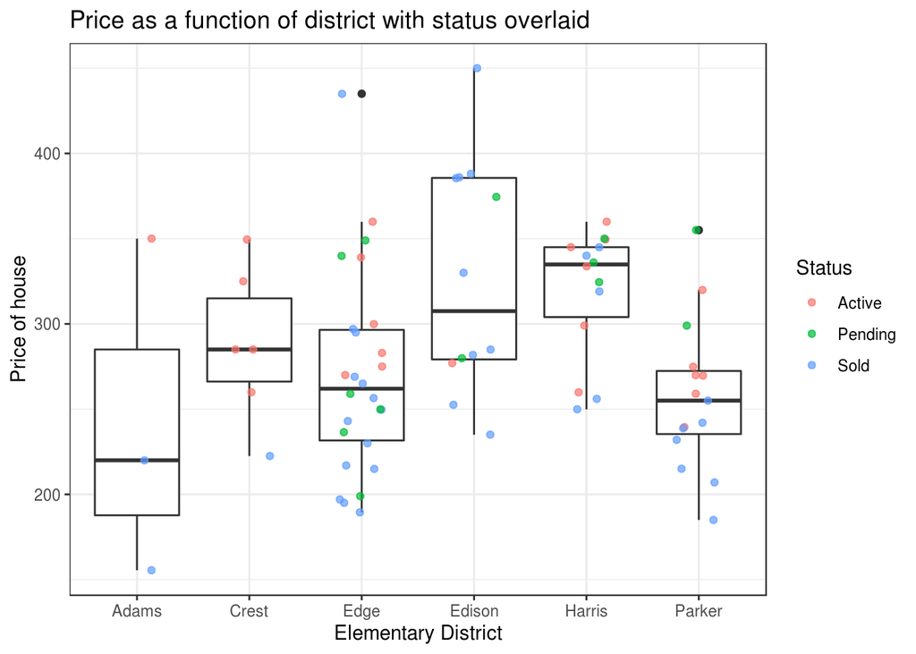

Figure 2.2: Status in District

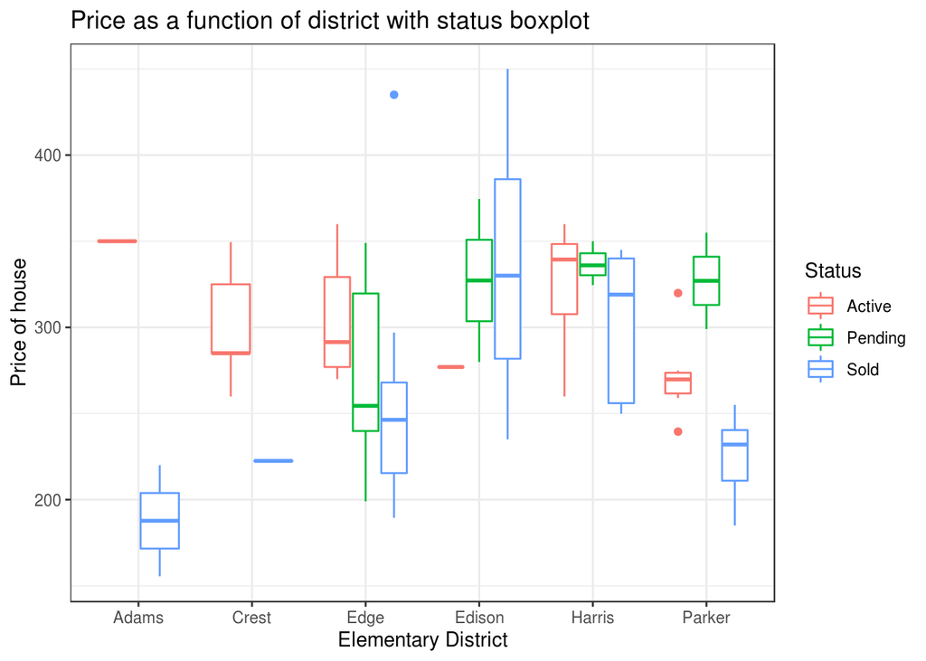

Figure 2.3: Status within District

### Exploratory Data Analysis conclusions

**Examine some of the variables relationships with price to help you determine which variables might be useful in an initial model. Explain your conclusions from this initial screening.**

# 3 Initial Modeling

Build initial model based upon data exploration:

```
##
## Call:
## lm(formula = price ~ lot + bedrooms + garagesize + yearbuilt +
##     size + status + elem, data = house)
##
## Residuals:
##     Min      1Q  Median      3Q     Max
## -93.474 -29.168  -2.023  26.840 103.936
##
## Coefficients:
##                Estimate Std. Error t value Pr(>|t|)
## (Intercept)   -205.9100   632.2096  -0.326  0.74573
## lot             10.4096     3.6231   2.873  0.00553 **
## bedrooms       -11.2723     8.8977  -1.267  0.20986
## garagesize       7.8650     9.4015   0.837  0.40600
## yearbuilt        0.1636     0.3216   0.509  0.61274
## size            78.2446    28.2140   2.773  0.00729 **
## statusPending  -19.9784    16.3083  -1.225  0.22512
## statusSold     -37.4955    13.8388  -2.709  0.00867 **
## elemCrest        1.7180    33.9024   0.051  0.95974
## elemEdge         6.0945    28.7387   0.212  0.83274
## elemEdison      85.8557    30.5066   2.814  0.00651 **
## elemHarris      52.2637    30.2461   1.728  0.08890 .
## elemParker     -14.7152    29.8235  -0.493  0.62344
## ---
## Signif. codes:  0 '***' 0.001 '**' 0.01 '*' 0.05 '.' 0.1 ' ' 1
##
## Residual standard error: 44.72 on 63 degrees of freedom
## Multiple R-squared:  0.5385, Adjusted R-squared:  0.4506
## F-statistic: 6.126 on 12 and 63 DF,  p-value: 5.551e-07
```

Graph `model1` summary information:

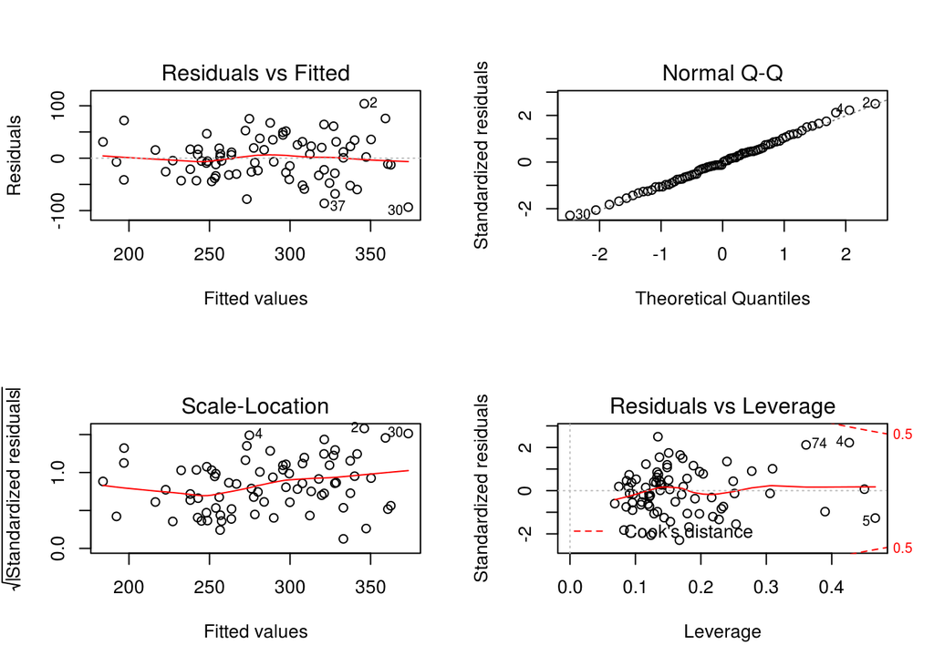

Figure 3.1: Model 1 Visual Summary

### Initial Modeling conclusions

**Using your conclusions from the exploratory data analysis, build a regression model and report your findings.**

The initial model was built using the data from the correlation information along with the insight gained from plotting the elemetary districts and the house status. When looking at the graphical data from the model in Figure 3.1 we can see that the data is overall about normal. We can see the Residuals vs Fitted is also very close to zero. The Scale-Location does have a small amount of downward curve to it, but not enough to pull the line far off the horizontal. The Residuals vs Leverage has a couple small deviations to the baseline like the Scale-Location graph. The outliers label will be explored to determine why they are outliers. This inital model does show an R-squared value of $0.5385$.

# 4 Model Modification

VIF analysis:

```
##                GVIF Df GVIF^(1/(2*Df))
## lot        1.345567  1        1.159986
## bedrooms   1.614790  1        1.270744
## garagesize 1.974418  1        1.405140
## yearbuilt  2.141406  1        1.463354
## size       1.347092  1        1.160643
## status     1.610568  2        1.126535
## elem       2.416596  5        1.092246
```

A closer look at outliers:

```r
house[c(74, 4, 5, 37), ]
```

```
## # A tibble: 4 x 11
##      id price  size   lot  bath bedrooms yearbuilt agestandardized garagesize
##   <dbl> <dbl> <dbl> <dbl> <dbl>    <dbl>     <dbl>           <dbl>      <dbl>
## 1    74  435   2.25    11     2        3      1979             0.9          2
## 2     4  350   1.44     6     1        2      1956            -1.4          1
## 3     5  156.  1.8      1     2        4      1994             2.4          1
## 4    37  235   1.71     5     1        3      1948            -2.2          1
## # … with 2 more variables: status <fct>, elem <fct>
```

```r
house %>%
  filter(bedrooms <= 2)
```

```
## # A tibble: 3 x 11
##      id price  size   lot  bath bedrooms yearbuilt agestandardized garagesize
##   <dbl> <dbl> <dbl> <dbl> <dbl>    <dbl>     <dbl>           <dbl>      <dbl>
## 1     4  350   1.44     6     1        2      1956            -1.4          1
## 2    21  299   1.99     8     3        2      2005             3.5          3
## 3    47  340.  2.05     5     2        2      1993             2.3          3
## # … with 2 more variables: status <fct>, elem <fct>
```

```r
house %>%
  filter(lot > 7)
```

```
## # A tibble: 2 x 11
##      id price  size   lot  bath bedrooms yearbuilt agestandardized garagesize
##   <dbl> <dbl> <dbl> <dbl> <dbl>    <dbl>     <dbl>           <dbl>      <dbl>
## 1    21   299  1.99     8     3        2      2005             3.5          3
## 2    74   435  2.25    11     2        3      1979             0.9          2
## # … with 2 more variables: status <fct>, elem <fct>
```

```r
house %>%
  filter(lot < 2)
```

```
## # A tibble: 7 x 11
##      id price  size   lot  bath bedrooms yearbuilt agestandardized garagesize
##   <dbl> <dbl> <dbl> <dbl> <dbl>    <dbl>     <dbl>           <dbl>      <dbl>
## 1     5  156.  1.8      1   2          4      1994             2.4          1
## 2    59  345   2.13     1   3.1        3      2005             3.5          2
## 3    60  336   2.13     1   3.1        3      2005             3.5          2
## 4    61  334.  2.13     1   3.1        3      2005             3.5          2
## 5    62  340   2.13     1   3.1        3      2005             3.5          2
## 6    63  345   2.13     1   3.1        3      2005             3.5          2
## 7    73  215   2.04     1   1.1        4      1936            -3.4          0
## # … with 2 more variables: status <fct>, elem <fct>
```

Create the new model:

```r
summary(model2 <- lm(price ~ bedrooms + bath + garagesize + status +
                       elem + size + lot + bedrooms:bath, house))
```

```
##
## Call:
## lm(formula = price ~ bedrooms + bath + garagesize + status +
##     elem + size + lot + bedrooms:bath, data = house)
##
## Residuals:
##    Min     1Q Median     3Q    Max
## -89.30 -23.67   2.11  25.03  95.96
##
## Coefficients:
##               Estimate Std. Error t value Pr(>|t|)
## (Intercept)    343.587    119.876   2.866  0.00567 **
## bedrooms       -80.626     33.128  -2.434  0.01784 *
## bath           -94.512     49.121  -1.924  0.05894 .
## garagesize       9.542      8.582   1.112  0.27049
## statusPending  -14.967     16.070  -0.931  0.35528
## statusSold     -34.272     13.560  -2.528  0.01405 *
## elemCrest       11.877     33.399   0.356  0.72333
## elemEdge        18.273     28.880   0.633  0.52924
## elemEdison      92.979     29.437   3.159  0.00245 **
## elemHarris      71.138     31.138   2.285  0.02577 *
## elemParker      12.543     31.620   0.397  0.69296
## size            68.339     29.972   2.280  0.02605 *
## lot              8.606      3.584   2.401  0.01937 *
## bedrooms:bath   29.609     14.030   2.110  0.03886 *
## ---
## Signif. codes:  0 '***' 0.001 '**' 0.01 '*' 0.05 '.' 0.1 ' ' 1
##
## Residual standard error: 43.52 on 62 degrees of freedom
## Multiple R-squared:  0.5699, Adjusted R-squared:  0.4797
## F-statistic:  6.32 on 13 and 62 DF,  p-value: 2.159e-07
```

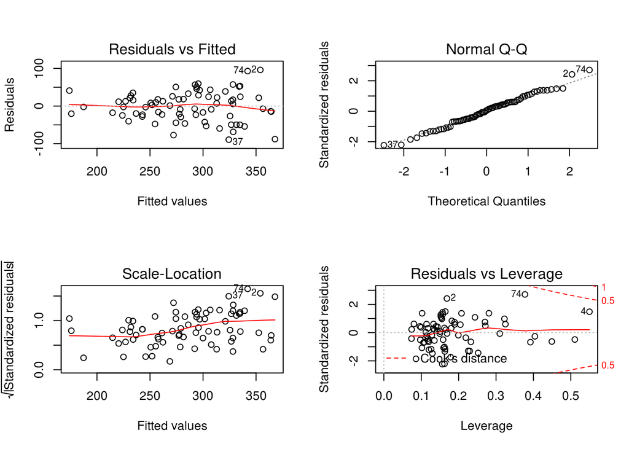

Figure 4.1: Model 2 Visual Summary

### Model Modification conclusions

**Consider modifying your model based upon your initial results and/or diagnostic plots from the model. Explain any modifications that you are making. Consider variance inflation factors for each predictor in your model and comment on that in your model selection process.**

Based upon the variance inflation factors the initial model is does not have a notable amount of multicollinearity. After taking a closer look at the outliers we can see that they stand out because they are the houses with the largest lot (74), the smallest house size (4), and the lowest priced house (5). It is easy to see why these showed up as outliers, yet there is no reason to modify them. It is also worth noting that the house (4) is an active listing, meaning the price reflected is what the seller wants and perhaps not an accurate value of the property. It would be helpful to match this number with an appraisal value if that were available to help determine if the listing price is inflated. After some reasoning and looking at a few other graphs of the data the model was adjusted to take into account some other factors. First the `yearbuilt` was removed as this did not show to have a significant value in the model. After that `bath` and the interaction between `bedrooms` and `bath` was added as many buyers would not choose a 4 bedroom 1 bathroom house. The combination of beds to baths is a more important consideration from personal experience buying houses.

# 5 Conclusions

Anova analsis of final model:

```
## Analysis of Variance Table
##
## Model 1: price ~ lot + bedrooms + garagesize + yearbuilt + size + status +
##     elem
## Model 2: price ~ bedrooms + bath + garagesize + status + elem + size +
##     lot + bedrooms:bath
##   Res.Df    RSS Df Sum of Sq      F  Pr(>F)
## 1     63 125986
## 2     62 117411  1    8575.1 4.5282 0.03732 *
## ---
## Signif. codes:  0 '***' 0.001 '**' 0.01 '*' 0.05 '.' 0.1 ' ' 1
```

Compared to the ‘all-in’ model:

```
##
## Call:
## lm(formula = price ~ ., data = house)
##
## Residuals:
##     Min      1Q  Median      3Q     Max
## -94.979 -28.850  -0.532  24.351  94.094
##
## Coefficients: (1 not defined because of singularities)
##                  Estimate Std. Error t value Pr(>|t|)
## (Intercept)     -202.1316   660.5568  -0.306  0.76065
## id                -0.2662     0.2796  -0.952  0.34494
## size              80.3003    32.0373   2.506  0.01488 *
## lot               10.3440     3.6717   2.817  0.00652 **
## bath               4.4328    11.7998   0.376  0.70847
## bedrooms         -12.9991     9.1684  -1.418  0.16134
## yearbuilt          0.1604     0.3352   0.479  0.63399
## agestandardized        NA         NA      NA       NA
## garagesize         6.1580     9.6116   0.641  0.52413
## statusPending    -17.8870    16.5880  -1.078  0.28514
## statusSold       -37.3552    13.9762  -2.673  0.00964 **
## elemCrest         12.4562    36.1419   0.345  0.73155
## elemEdge          13.0455    30.4176   0.429  0.66952
## elemEdison        91.7657    31.7622   2.889  0.00534 **
## elemHarris        61.8989    33.0168   1.875  0.06561 .
## elemParker        -6.9925    31.0327  -0.225  0.82248
## ---
## Signif. codes:  0 '***' 0.001 '**' 0.01 '*' 0.05 '.' 0.1 ' ' 1
##
## Residual standard error: 45.03 on 61 degrees of freedom
## Multiple R-squared:  0.5468, Adjusted R-squared:  0.4428
## F-statistic: 5.258 on 14 and 61 DF,  p-value: 2.203e-06
```

```
##
## Call:
## lm(formula = price ~ bedrooms + bath + garagesize + status +
##     elem + size + lot + bedrooms:bath, data = house)
##
## Residuals:
##    Min     1Q Median     3Q    Max
## -89.30 -23.67   2.11  25.03  95.96
##
## Coefficients:
##               Estimate Std. Error t value Pr(>|t|)
## (Intercept)    343.587    119.876   2.866  0.00567 **
## bedrooms       -80.626     33.128  -2.434  0.01784 *
## bath           -94.512     49.121  -1.924  0.05894 .
## garagesize       9.542      8.582   1.112  0.27049
## statusPending  -14.967     16.070  -0.931  0.35528
## statusSold     -34.272     13.560  -2.528  0.01405 *
## elemCrest       11.877     33.399   0.356  0.72333
## elemEdge        18.273     28.880   0.633  0.52924
## elemEdison      92.979     29.437   3.159  0.00245 **
## elemHarris      71.138     31.138   2.285  0.02577 *
## elemParker      12.543     31.620   0.397  0.69296
## size            68.339     29.972   2.280  0.02605 *
## lot              8.606      3.584   2.401  0.01937 *
## bedrooms:bath   29.609     14.030   2.110  0.03886 *
## ---
## Signif. codes:  0 '***' 0.001 '**' 0.01 '*' 0.05 '.' 0.1 ' ' 1
##
## Residual standard error: 43.52 on 62 degrees of freedom
## Multiple R-squared:  0.5699, Adjusted R-squared:  0.4797
## F-statistic:  6.32 on 13 and 62 DF,  p-value: 2.159e-07
```

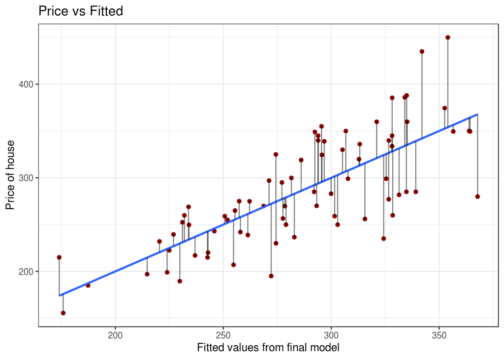

Figure 5.1: Price compared to Final Model Line

### 95% Confindence Intervals of the final model

```
##                     2.5 %     97.5 %
## (Intercept)    103.958470 583.216268
## bedrooms      -146.847877 -14.403873
## bath          -192.703889   3.680293
## garagesize      -7.612647  26.695803
## statusPending  -47.090791  17.156630
## statusSold     -61.377485  -7.166980
## elemCrest      -54.885963  78.640893
## elemEdge       -39.457270  76.003779
## elemEdison      34.134565 151.822539
## elemHarris       8.893395 133.382900
## elemParker     -50.664561  75.751480
## size             8.426603 128.251766
## lot              1.440518  15.770941
## bedrooms:bath    1.563531  57.653794
```

### 95% Confidence Interval of mean model response

```r
house_mean <-  data.frame(bedrooms = mean(house$bedrooms), bath = mean(house$bath),
                          garagesize = mean(house$bath), status = "Sold",
                          elem = "Edge", size = mean(house$size), lot = mean(house$lot))
# Confidence Interval for house2
predict(model2, house_mean, interval = "confidence")
```

```
##       fit      lwr      upr
## 1 256.365 232.6423 280.0877
```

### 95% Confidence Interval of prediction

```r
house2 = data.frame(bedrooms = 3, bath = 2, garagesize = 2, status = "Active",
                    elem = "Edge", size = 1.7, lot = 4)
# Prediction Interval for house2
predict(model2, house2, interval = "predict")
```

```
##        fit      lwr     upr
## 1 278.2941 187.2311 369.357
```

**Present your final model and diagnostic plots in support of that final model. In that presentation of the final model, comment on the R-squared value and its interpretation, give 95% confidence intervals for each of the β coefficients in your model, and illustrate your model’s use with a 95% confidence interval for the mean response and a 95% prediction interval for individual response for a hypothetical house of your choosing.**

The comparing the models with `anova()` we can see that the F-statistic of `model2` is stronger. From a basic comparison with a linear model which puts all data variables into the model we have improved our overall R-squared value from both the ‘all-in’ model and our `model1` even though we have removed variables for the final model. As we can see from Figure 4.1 we have been able to smooth out our baselines as much as would seem reasonable and looking at the graphs we can reason that the model has no outstanding issues to be addressed. We can see from looking at Figure 5.1 that the predicted model line appears to be relatively in the center of the actual values with segments representing the residuals.